# HW #4 - Multiple Regression

Author

David Gonzalez Chavez

# Problem Set Part 1

## Question 1

### a) What is the error for Observation A?

The error for Observation A is 1.

### b) What is the residual for Observation A?

The residual for Observation A is 0.9.

## Question 2

Top-Left: Y ~ X + D Top-Right: Y ~ X + D Bottom-Left: Y ~ X Bottom-Right: Not possible

## Question 3

### a) How many additional hours worked is associated with a one-unit increase of years of education when controlling for number of children?

76.185 hours

### b) What is the standard error on the “children under 5” coefficient when not controlling for years of education?

19.693 hours

### c) In the third model, what is the predicted number of hours worked for a woman with zero children and zero years of education?

306.553 hours

### d) In the second model, how many hours worked would the model predict for a woman with 2 children and 10 years of education?

778.965 hours

### e) In models 2 and 3, is the coefficient on children under 5 “statistically significantly” different from 0 at the 95% level? How many standard deviations away from 0 are they? And how do we call this statistic?

Yes, the coefficients on both are “statistically significant”.

For model 2, the coefficient is 12.1288275 standard deviations away from 0, which is well beyond the 1.96 threshold for 95% confidence.

For model 3, the coefficient is 13.0280602 standard deviations away from 0, which is well beyond the 1.96 threshold for 95% confidence.

This statistic is called the z-score.

## Question 4

### a) What is the relationship between a one-year increase in education and the number of annual hours worked?

A one-year increase in education (from zero years of education) is associated with an increase of 108.649 annual hours worked.

### b) What is the relationship between a one-year increase in education and annual hours worked if the current level of education is 16?

A one-year increase in education is associated with an increase of 58.057 annual hours worked.

### c) Is the relationship between education and hours worked getting more or less positive for higher values of education?

The relationship between education and hours worked is getting less positive for higher values of education.

### d) What would be one reason not to include a whole bunch of additional powers of education in this model (Edu3, Edu4, and so on)?

Adding additional powers of education might lead to overfitting, where the data fits the sample too well but wouldn’t generalize well.

## Question 5

### a) Interpret the coefficient on “Homeowner”. Is this coefficient “statistically significantly” different from 0 at the 95% level?

The z-statistic for Homeowner is 1.5239802 which is below the 1.96 threshold for 95% confidence, therefore this coefficient is not “statistically significant.”

### b) According to the model, how many fewer hours do people with 4 children under the age of 5 work than people with 3 children under the age of 5?

People with 4 children under 5 work 150.492 hours less than those with only 3.

### c) From this table alone can we tell whether there’s a “statistically significant” difference in hours worked between having 2 children and having 3? How could we test that?

Yes, by constructing two 95% confidence intervals for the effect of 2 and 3 children.

The 95% confidence interval for 2 children under 5 is -627.564 to -424.448.

The 95% confidence interval for 3 children under 5 is -995.66424 to -551.15976.

Because these confidence intervals overlap, there is not a “statistically significant” difference between the effect of having 2 vs. 3 children.

## Question 6

### a) In Model 1, what is the relationship between a one-unit increase in Education and annual hours worked?

A one-unit increase in education has difference effects for homeowners and non-homeowners.

For non-homeowners, the effect is 110.073 hours.

For homeowners, the effect is 56.079 hours.

### b) Interpret the coefficient on Homeowner × Education in Model 1

For homeowners, the effect of education is weaker than for non-homeowners. Instead of an effect of 110.073 for non-homeowners, homeowners have an effect of 110.073 - 53.994 (53.994 being the coefficient on Homeowner X Education).

### c) Interpret the coefficient on Education in Model 2. Note that the dependent variable is log(Annual Hours Worked).

For a non-homeowner, an increase of 1 year in education results in an increase in annual hours worked of 0.0692955%

### d) Interpret the coefficient on log(Education) in Model 3 using percentage change in education.

A 1% change in education is associated with an increase of 8.32347 hours worked.

### e) Why do you think the sample size is different in model 2?

The sample size is different in model 2 as the DV is the log of hours worked, and for anyone with 0 hours worked the log wouldn’t be possible and therefore they would be taken out of the sample.

## Question 7

2. When error terms are correlated across time, such that knowing the error term in one period gives us some information about the error term in the next period.

## Question 8

b, c, e

## Question 9

They can use sample weights. They should determine the proportion of each demographic in the population, and weight individuals within their sample up/down to reach a weighted proportion equal to the population for each demogrpahic.

## Question 10

a

# Problem Set Part 2

```r
d <- read_csv("dengue.csv")
```

## 1: Run an OLS regression using average humidity and temperature to predict whether dengue was observed in the area, and plot a summary table of the results.

```r
m1 <- lm(NoYes ~ humid + temp,
         data = d)

summary(m1)
```

```
Call:
lm(formula = NoYes ~ humid + temp, data = d)

Residuals:
    Min      1Q  Median      3Q     Max
-1.1055 -0.1442 -0.0062  0.1767  1.3624

Coefficients:
             Estimate Std. Error t value Pr(>|t|)
(Intercept) -0.407272   0.019033 -21.398   <2e-16 ***
humid        0.052851   0.001955  27.034   <2e-16 ***
temp        -0.003286   0.001778  -1.848   0.0648 .
---
Signif. codes:  0 '***' 0.001 '**' 0.01 '*' 0.05 '.' 0.1 ' ' 1

Residual standard error: 0.331 on 1995 degrees of freedom
  (2 observations deleted due to missingness)
Multiple R-squared:  0.5492,    Adjusted R-squared:  0.5488
F-statistic:  1215 on 2 and 1995 DF,  p-value: < 2.2e-16
```

## 2: Our dependent variable is binary, and we’re getting predictions below zero, which we might not want. Rerun the regression from the previous question but as a logit model, report and interpret the marginal effects of both slope coefficients.

```r
m2 <- glm(NoYes ~ humid + temp,
         data = d,
         family = "binomial")

summary(m2)
```

```
Call:
glm(formula = NoYes ~ humid + temp, family = "binomial", data = d)

Coefficients:
            Estimate Std. Error z value Pr(>|z|)
(Intercept) -6.59219    0.30290 -21.764   <2e-16 ***
humid        0.30474    0.01985  15.350   <2e-16 ***
temp         0.03987    0.01933   2.063   0.0391 *
---
Signif. codes:  0 '***' 0.001 '**' 0.01 '*' 0.05 '.' 0.1 ' ' 1

(Dispersion parameter for binomial family taken to be 1)

    Null deviance: 2711.7  on 1997  degrees of freedom
Residual deviance: 1357.0  on 1995  degrees of freedom
  (2 observations deleted due to missingness)
AIC: 1363

Number of Fisher Scoring iterations: 6
```

An increase of 1 point of humidity is associated with an increase in the log odds of having dengue of 0.30474. An increase of 1 degree of temperature is associated with an increase in the log odds of having dengue of 0.03987.

## 3: Now let’s say we’re directly interested in the relationship between temperature and humidity. Run an OLS regression of humidity on temperature. Calculate the residuals of that regression, and then make a plot that will let you evaluate whether there is likely heteroskedasticity in the model. Rerun the model with heteroskedasticity-robust standard errors. Show both models, and say whether you think there is heteroskedasticity.

Note: remove NAs for the variable humid on the data before running themodel so the residuals line up properly.

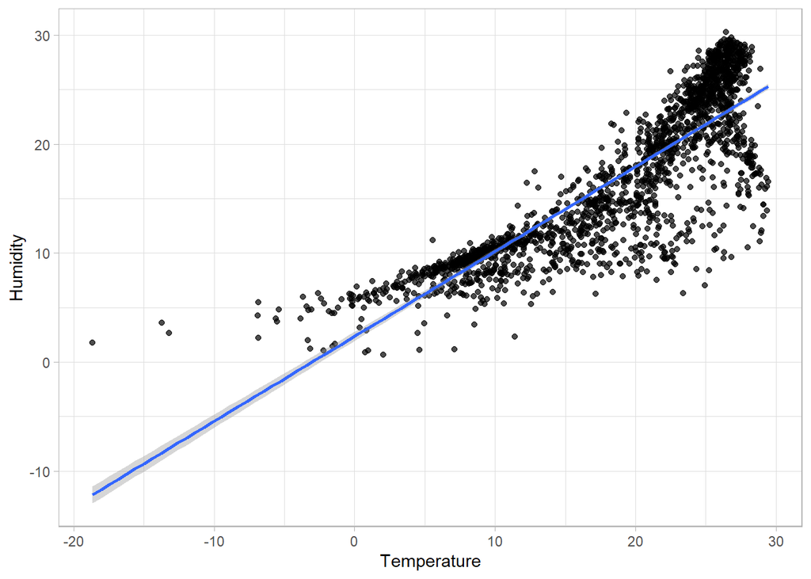

```r
library(sandwich)
library(lmtest)

d <- d |>
  drop_na(humid)

m3 <- lm(humid ~ temp,
        data = d)

ggplot(aes(x = temp,
           y = humid),
       data = d) +
  geom_point(alpha = .7) +
  geom_smooth(method = "lm") +
  labs(x = "Temperature",
       y = "Humidity")
```

Regular Model

```r
summary(m3)
```

```
Call:
lm(formula = humid ~ temp, data = d)

Residuals:
     Min       1Q   Median       3Q      Max
-14.7416  -1.8751   0.4252   2.5564  13.9461

Coefficients:
            Estimate Std. Error t value Pr(>|t|)
(Intercept)  2.36152    0.21141   11.17   <2e-16 ***
temp         0.77885    0.01052   74.05   <2e-16 ***
---
Signif. codes:  0 '***' 0.001 '**' 0.01 '*' 0.05 '.' 0.1 ' ' 1

Residual standard error: 3.79 on 1996 degrees of freedom
Multiple R-squared:  0.7331,    Adjusted R-squared:  0.733
F-statistic:  5483 on 1 and 1996 DF,  p-value: < 2.2e-16
```

Heteroskedasticity-Robust Standard Errors

```r
coeftest(m3, vcov. = vcovHC(m3, type = "HC0"))
```

```
t test of coefficients:

            Estimate Std. Error t value  Pr(>|t|)
(Intercept) 2.361523   0.195816   12.06 < 2.2e-16 ***
temp        0.778849   0.011523   67.59 < 2.2e-16 ***
---
Signif. codes:  0 '***' 0.001 '**' 0.01 '*' 0.05 '.' 0.1 ' ' 1
```

## 4: In the graph in the last problem you may have noticed that for certain ranges of temperate, the errors were clearly nonzero on average. This can indicate a functional form problem. Run the model from the previous question again (with heteroskedasticity-robust standard errors), but this time use the logarithm of humidity in place of humidity. Add a sentence interpreting the coefficient on temperature.

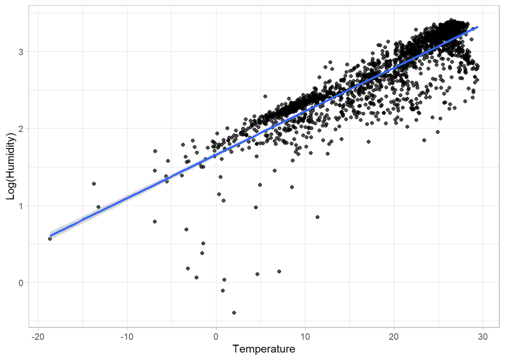

```r
m4 <- lm(log(humid) ~ temp,
        data = d)

ggplot(aes(x = temp,
           y = log(humid)),
       data = d) +
  geom_point(alpha = .7) +
  geom_smooth(method = "lm") +
  labs(x = "Temperature",
       y = "Log(Humidity)")
```

Heteroskedasticity-Robust Standard Errors

```r
coeftest(m4, vcov. = vcovHC(m3, type = "HC0"))
```

```
t test of coefficients:

            Estimate Std. Error t value    Pr(>|t|)
(Intercept) 1.659049   0.195816  8.4725   < 2.2e-16 ***
temp        0.056482   0.011523  4.9016 0.000001027 ***
---
Signif. codes:  0 '***' 0.001 '**' 0.01 '*' 0.05 '.' 0.1 ' ' 1
```

For every increase in temperature of 1, the humidity increases by 5.8107569%.

## 5: Bonus question: figure out how I decided on a form where you log humidity and keep temperature linear.

You could’ve done this by looking at the data, such as making a plot of the residuals.

You could also have assumed this type of relationship from the real-world implications of increasing temperature on humidity. You could expect that at higher temperatures, the impact of increasing the temperature by one would have a greater impact on humidity as water would be much more likely to evaporate and thus enter the atsmophere to raise humidity compared to at a lower temperature, where such a small increase wouldn’t bring water meaningfully closer to the point of evaporating.